# Lab 5

- Show All Code
- Hide All Code
- View Source

Author

Krishna Agrawal

```r
library(tidyverse)
library(here)
library(lubridate)
```

```r
# Code for question 1!
surveys <- read_csv(here("Week#2", "Lab_Week_2", "surveys.csv"))
```

## 1) Revisiting Lab #2

**1. Reorder the species so the boxplots for weights go in descending order (largest to smallest).**

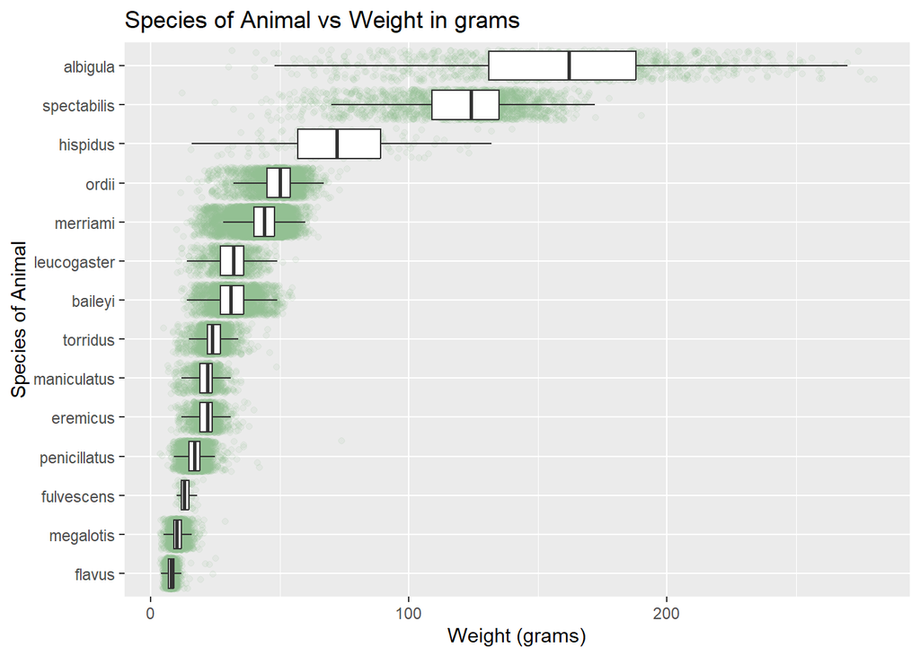

```r
ggplot(data = surveys,
       mapping = aes(y = fct_reorder(species,weight),
                     x = weight)) +
   geom_jitter(color = "darkseagreen",
               alpha = .1) +
   geom_boxplot(outlier.shape = NA) +
   labs(y = "Species of Animal",
        x = "Weight (grams)",
        title = "Species of Animal vs Weight in grams")
```

**2. Now that you’ve reordered, look at your y-axis label. That’s long! Let’s take Will Chase’s advice and move the y-axis label to the top of the plot.**

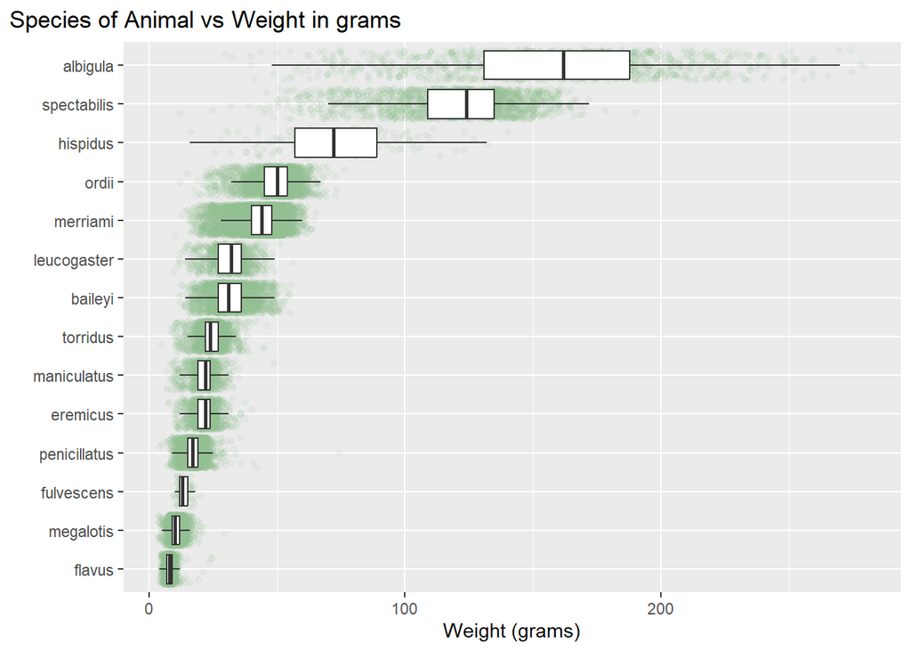

```r
ggplot(data = surveys,
       mapping = aes(y = fct_reorder(species,weight),
                     x = weight)) +
   geom_jitter(color = "darkseagreen",
               alpha = .1) +
   geom_boxplot(outlier.shape = NA) +
   labs(y = '',
        x = "Weight (grams)",
        title = "Species of Animal vs Weight in grams") +
   theme(plot.title.position = 'plot')
```

## **2 Time-Series Plot**

**1. Create a visualization how weights vary for each genus over the duration of the study.**

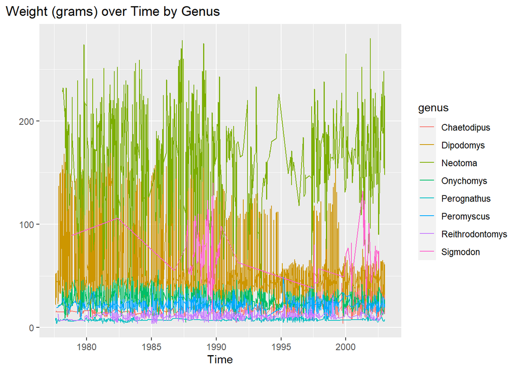

```r
date_survey <- surveys |>
  mutate(date = ymd(date))


ggplot(data = date_survey,
       mapping = aes(y = weight,
                     x = date,
                     color = genus)) +
  geom_line() +
  labs(y = '',
        x = "Time",
        title = "Weight (grams) over Time by Genus") +
   theme(plot.title.position = 'plot')
```

**2. Calculate and plot the mean weight for each genus for each year.**

This should look much less busy! However, you should notice that the legend still goes in alphabetical order.

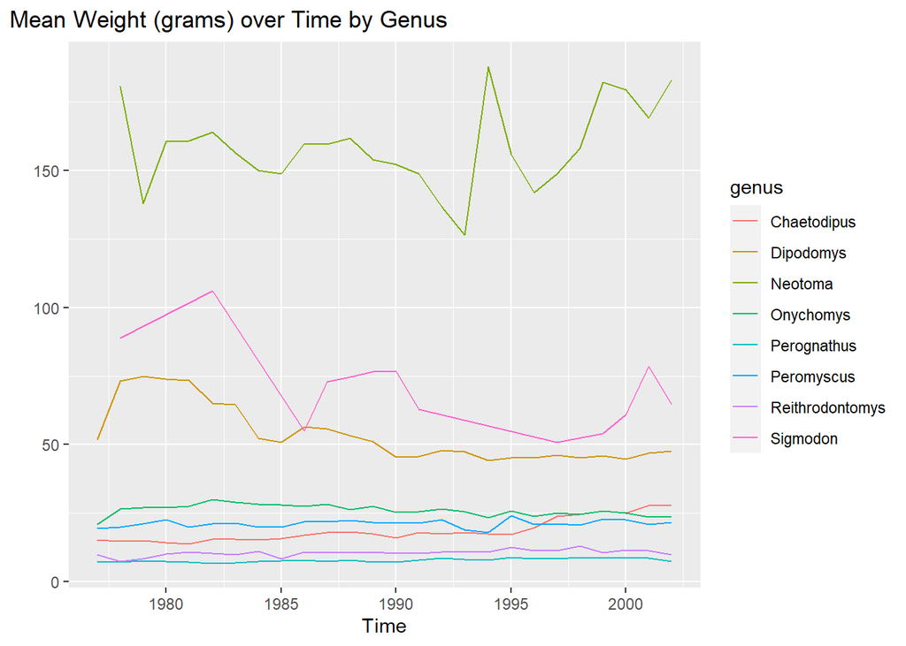

```r
mean_weight_survey <- date_survey |>
  mutate(year = year(date)) |>
  group_by(genus, year) |>
  summarise(mean_weight = mean(weight))

ggplot(data = mean_weight_survey,
       mapping = aes(y = mean_weight,
                     x = year,
                     color = genus)) +
  geom_line() +
  labs(y = '',
        x = "Time",
        title = "Mean Weight (grams) over Time by Genus") +
   theme(plot.title.position = 'plot')
```

**3 & 4 Reorder the lines so the mean weights go in descending order (largest to smallest).**

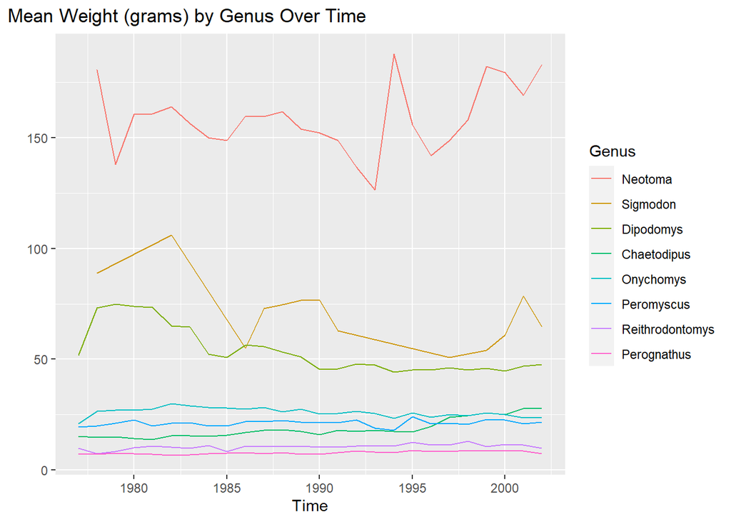

```r
ggplot(data = mean_weight_survey,
       mapping = aes(y = mean_weight,
                     x = year,
                     color = fct_reorder2(.f = genus,
                                          .y = mean_weight,
                                          .x = year))) +
  geom_line() +
  labs(y = '',
       x = "Time",
       title = "Mean Weight (grams) by Genus Over Time") +
  guides(color = guide_legend(title = "Genus")) +
  theme(plot.title.position = 'plot')
```

```r
#guides function was obtained from : https://www.geeksforgeeks.org/how-to-change-legend-title-in-ggplot2-in-r/
```

## **3 Caputures over the Week**

**1 & 2) Create a visualization of the number of rodents captured each day of the week.**

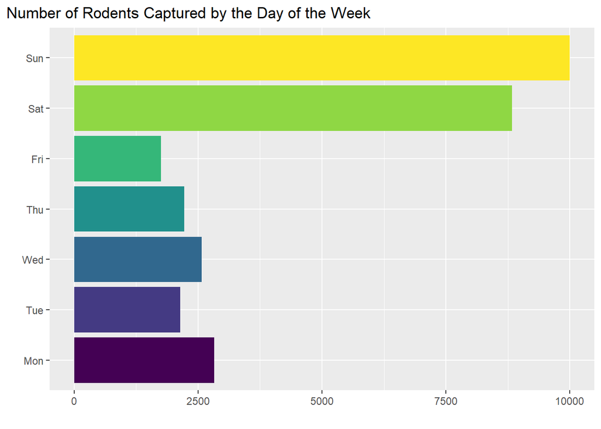

```r
count_survey <- date_survey |>
  drop_na(date) |>
  mutate(day_week = wday(date,
                        label = TRUE),
         day_week = factor(day_week,
                          levels = c("Mon",
                                     "Tue",
                                     "Wed",
                                     "Thu",
                                     "Fri",
                                     "Sat",
                                     "Sun"))
         ) |>
  count(day_week)


ggplot(data = count_survey,
       mapping = aes(y = day_week,
                     x = n,
                     fill = day_week)) +
  geom_bar(stat = "identity",
           show.legend = FALSE) +
  labs(y = '',
       x = "",
       title = "Number of Rodents Captured by the Day of the Week") +
  theme(plot.title.position = 'plot')
```

**3. Collapse Monday through Friday into a `"Weekday"` level, and collapse Saturday and Sunday into a `"Weekend"` level. Plot the number of rodents captured between the two groups.**

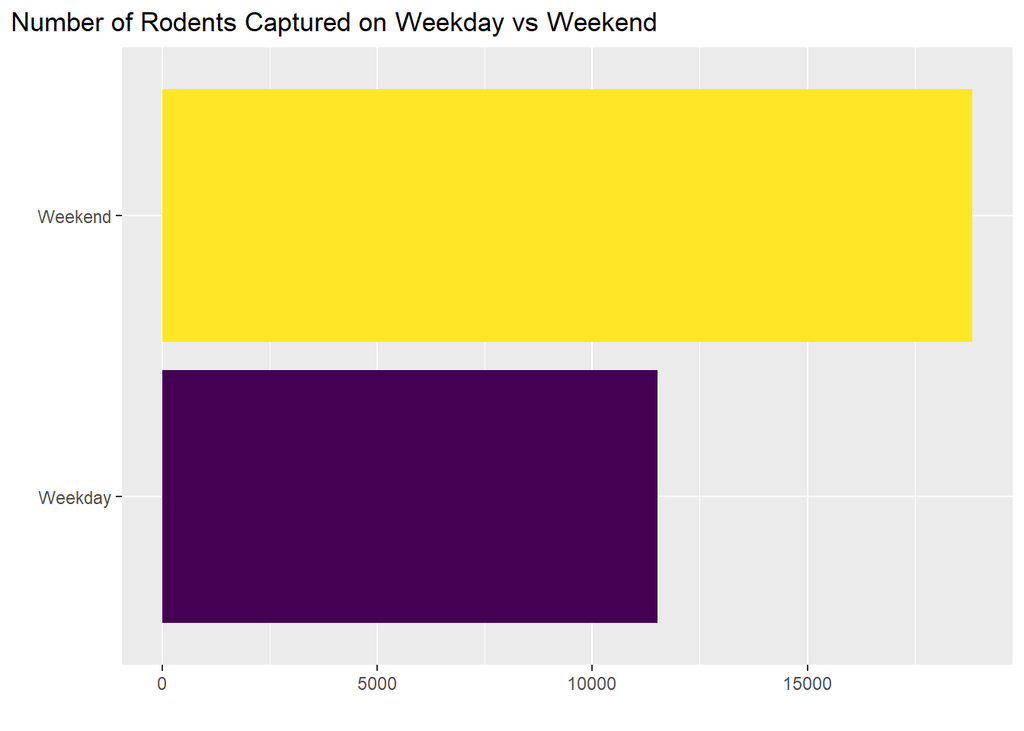

```r
collapsed_survey <- count_survey |>
  mutate(day_week = fct_collapse(day_week,
    Weekday = c("Mon", "Tue", "Wed", "Thu", "Fri"),
    Weekend = c("Sat", "Sun")
    ))

ggplot(data = collapsed_survey,
     mapping = aes(y = day_week,
                   x = n,
                   fill = day_week)) +
geom_bar(stat = "identity",
         show.legend = FALSE) +
labs(y = '',
     x = "",
     title = "Number of Rodents Captured on Weekday vs Weekend") +
theme(plot.title.position = 'plot')
```